# STEP PRESENTATION

```python
import pandas as pd
import numpy as np
import seaborn as sns
import matplotlib.pyplot as plt
```

```python
#Importing dataset
df = pd.read_csv("telecom.csv")
```

```python
#to get the shape of the dataframe using pandas
df.shape
```

```
(7043, 21)
```

```python
df.columns
```

```
Index(['customerID', 'gender', 'SeniorCitizen', 'Partner', 'Dependents',
       'tenure', 'PhoneService', 'MultipleLines', 'InternetService',
       'OnlineSecurity', 'OnlineBackup', 'DeviceProtection', 'TechSupport',
       'StreamingTV', 'StreamingMovies', 'Contract', 'PaperlessBilling',
       'PaymentMethod', 'MonthlyCharges', 'TotalCharges', 'Churn'],
      dtype='object')
```

```python
df.info
```

```
<bound method DataFrame.info of       customerID  gender  SeniorCitizen Partner Dependents  tenure  \
0     7590-VHVEG  Female              0     Yes         No       1
1     5575-GNVDE    Male              0      No         No      34
2     3668-QPYBK    Male              0      No         No       2
3     7795-CFOCW    Male              0      No         No      45
4     9237-HQITU  Female              0      No         No       2
...          ...     ...            ...     ...        ...     ...
7038  6840-RESVB    Male              0     Yes        Yes      24
7039  2234-XADUH  Female              0     Yes        Yes      72
7040  4801-JZAZL  Female              0     Yes        Yes      11
7041  8361-LTMKD    Male              1     Yes         No       4
7042  3186-AJIEK    Male              0      No         No      66

     PhoneService     MultipleLines InternetService OnlineSecurity  ...  \
0              No  No phone service             DSL             No  ...
```

[output cut: 51 more lines]

```python
df["DeviceProtection"].describe()
```

```
count     7043
unique       3
top         No
freq      3095
Name: DeviceProtection, dtype: object
```

```python
df.describe(include=["object", "bool"])
```

|  | customerID | gender | Partner | Dependents | PhoneService | MultipleLines | InternetService | OnlineSecurity | OnlineBackup | DeviceProtection | TechSupport | StreamingTV | StreamingMovies | Contract | PaperlessBilling | PaymentMethod | TotalCharges | Churn |
| --- | --- | --- | --- | --- | --- | --- | --- | --- | --- | --- | --- | --- | --- | --- | --- | --- | --- | --- |
| count | 7043 | 7043 | 7043 | 7043 | 7043 | 7043 | 7043 | 7043 | 7043 | 7043 | 7043 | 7043 | 7043 | 7043 | 7043 | 7043 | 7043 | 7043 |
| unique | 7043 | 2 | 2 | 2 | 2 | 3 | 3 | 3 | 3 | 3 | 3 | 3 | 3 | 3 | 2 | 4 | 6531 | 2 |
| top | 7590-VHVEG | Male | No | No | Yes | No | Fiber optic | No | No | No | No | No | No | Month-to-month | Yes | Electronic check |  | No |
| freq | 1 | 3555 | 3641 | 4933 | 6361 | 3390 | 3096 | 3498 | 3088 | 3095 | 3473 | 2810 | 2785 | 3875 | 4171 | 2365 | 11 | 5174 |

```python
#Checking for missing values
missing_values = df.isnull().sum()
total_cells = np.product(df.shape)
total_missing = missing_values_count.sum()
missing_values [0:10]
```

```
customerID         0
gender             0
SeniorCitizen      0
Partner            0
Dependents         0
tenure             0
PhoneService       0
MultipleLines      0
InternetService    0
OnlineSecurity     0
dtype: int64
```

```python
#checking sample rows for missing data and checking what dataset looks like
df.sample(5)
```

|  | customerID | gender | SeniorCitizen | Partner | Dependents | tenure | PhoneService | MultipleLines | InternetService | OnlineSecurity | ... | DeviceProtection | TechSupport | StreamingTV | StreamingMovies | Contract | PaperlessBilling | PaymentMethod | MonthlyCharges | TotalCharges | Churn |
| --- | --- | --- | --- | --- | --- | --- | --- | --- | --- | --- | --- | --- | --- | --- | --- | --- | --- | --- | --- | --- | --- |
| 5453 | 4012-YCFAI | Male | 0 | Yes | No | 60 | Yes | No | DSL | Yes | ... | No | Yes | No | No | Two year | Yes | Mailed check | 61.35 | 3766.2 | No |
| 217 | 0230-WEQUW | Male | 0 | Yes | No | 66 | No | No phone service | DSL | Yes | ... | Yes | Yes | Yes | No | Two year | Yes | Bank transfer (automatic) | 56.60 | 3789.2 | No |
| 250 | 4075-JFPGR | Female | 0 | Yes | No | 51 | Yes | No | Fiber optic | Yes | ... | Yes | No | Yes | No | One year | Yes | Electronic check | 93.50 | 4619.55 | No |
| 2960 | 5590-BYNII | Male | 0 | No | No | 22 | Yes | Yes | Fiber optic | Yes | ... | No | No | Yes | Yes | Month-to-month | Yes | Electronic check | 100.75 | 2095 | Yes |
| 4101 | 9780-FKVVF | Male | 0 | No | No | 6 | Yes | No | DSL | Yes | ... | No | No | No | Yes | Month-to-month | Yes | Bank transfer (automatic) | 59.15 | 336.7 | No |

5 rows × 21 columns

```python
df = df.drop(['customerID'], axis = 1)
df.head()
```

|  | gender | SeniorCitizen | Partner | Dependents | tenure | PhoneService | MultipleLines | InternetService | OnlineSecurity | OnlineBackup | DeviceProtection | TechSupport | StreamingTV | StreamingMovies | Contract | PaperlessBilling | PaymentMethod | MonthlyCharges | TotalCharges | Churn |
| --- | --- | --- | --- | --- | --- | --- | --- | --- | --- | --- | --- | --- | --- | --- | --- | --- | --- | --- | --- | --- |
| 0 | Female | 0 | Yes | No | 1 | No | No phone service | DSL | No | Yes | No | No | No | No | Month-to-month | Yes | Electronic check | 29.85 | 29.85 | No |
| 1 | Male | 0 | No | No | 34 | Yes | No | DSL | Yes | No | Yes | No | No | No | One year | No | Mailed check | 56.95 | 1889.5 | No |
| 2 | Male | 0 | No | No | 2 | Yes | No | DSL | Yes | Yes | No | No | No | No | Month-to-month | Yes | Mailed check | 53.85 | 108.15 | Yes |
| 3 | Male | 0 | No | No | 45 | No | No phone service | DSL | Yes | No | Yes | Yes | No | No | One year | No | Bank transfer (automatic) | 42.30 | 1840.75 | No |
| 4 | Female | 0 | No | No | 2 | Yes | No | Fiber optic | No | No | No | No | No | No | Month-to-month | Yes | Electronic check | 70.70 | 151.65 | Yes |

```python
df.tail()
```

|  | gender | SeniorCitizen | Partner | Dependents | tenure | PhoneService | MultipleLines | InternetService | OnlineSecurity | OnlineBackup | DeviceProtection | TechSupport | StreamingTV | StreamingMovies | Contract | PaperlessBilling | PaymentMethod | MonthlyCharges | TotalCharges | Churn |
| --- | --- | --- | --- | --- | --- | --- | --- | --- | --- | --- | --- | --- | --- | --- | --- | --- | --- | --- | --- | --- |
| 7038 | Male | 0 | Yes | Yes | 24 | Yes | Yes | DSL | Yes | No | Yes | Yes | Yes | Yes | One year | Yes | Mailed check | 84.80 | 1990.5 | No |
| 7039 | Female | 0 | Yes | Yes | 72 | Yes | Yes | Fiber optic | No | Yes | Yes | No | Yes | Yes | One year | Yes | Credit card (automatic) | 103.20 | 7362.9 | No |
| 7040 | Female | 0 | Yes | Yes | 11 | No | No phone service | DSL | Yes | No | No | No | No | No | Month-to-month | Yes | Electronic check | 29.60 | 346.45 | No |
| 7041 | Male | 1 | Yes | No | 4 | Yes | Yes | Fiber optic | No | No | No | No | No | No | Month-to-month | Yes | Mailed check | 74.40 | 306.6 | Yes |
| 7042 | Male | 0 | No | No | 66 | Yes | No | Fiber optic | Yes | No | Yes | Yes | Yes | Yes | Two year | Yes | Bank transfer (automatic) | 105.65 | 6844.5 | No |

```python
df['TotalCharges'] = pd.to_numeric(df.TotalCharges, errors='coerce')
df.isnull().sum()
```

```
gender               0
SeniorCitizen        0
Partner              0
Dependents           0
tenure               0
PhoneService         0
MultipleLines        0
InternetService      0
OnlineSecurity       0
OnlineBackup         0
DeviceProtection     0
TechSupport          0
StreamingTV          0
StreamingMovies      0
Contract             0
PaperlessBilling     0
PaymentMethod        0
MonthlyCharges       0
TotalCharges        11
Churn                0
dtype: int64
```

```python
#Filling the Totalcharges column with the mean
```

```python
df.fillna(df["TotalCharges"].mean(),inplace=True)
```

```python
#checking to see the missing values in the Totalcharges column
```

```python
df["TotalCharges"].isnull().sum()
```

```
0
```

gain insights into the proportion of customers who have churned and the proportion who have opted for tech support

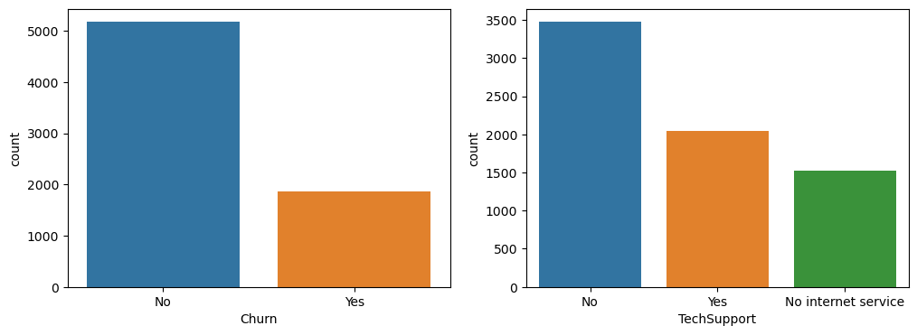

```python
fig, axes = plt.subplots(nrows=1, ncols=2, figsize=(12, 4))
sns.countplot(x="Churn", data=df, ax=axes[0])
sns.countplot(x="TechSupport", data=df, ax=axes[1])
plt.show()
```

To gain insights into the proportion of customers who have churned to the proportion who have OnlineSecurity

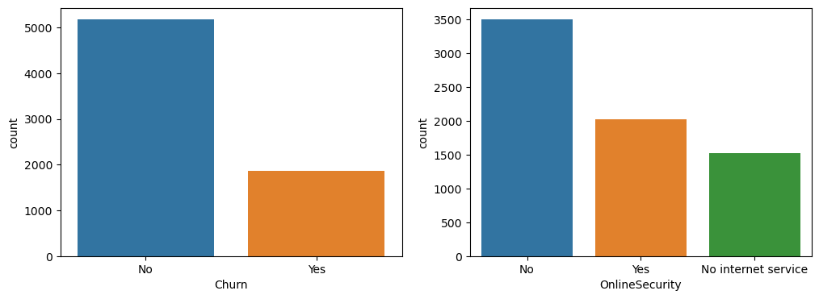

```python
fig, axes = plt.subplots(nrows=1, ncols=2, figsize=(12, 4))
sns.countplot(x="Churn", data=df, ax=axes[0])
sns.countplot(x="OnlineSecurity", data=df, ax=axes[1])
plt.show()
```

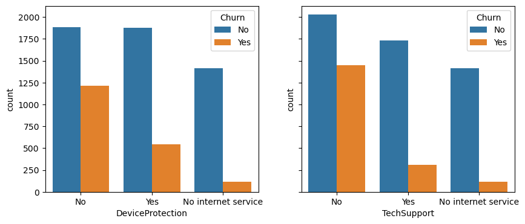

```python
fig, axes = plt.subplots(1, 2, sharey=True, figsize=(10, 4))

sns.countplot(x="DeviceProtection", hue="Churn", data=df, ax=axes[0])
sns.countplot(x="TechSupport", hue="Churn", data=df, ax=axes[1]);
```

From the countplot above the customers with no device protection churned more and the customers with no techsupport churned more

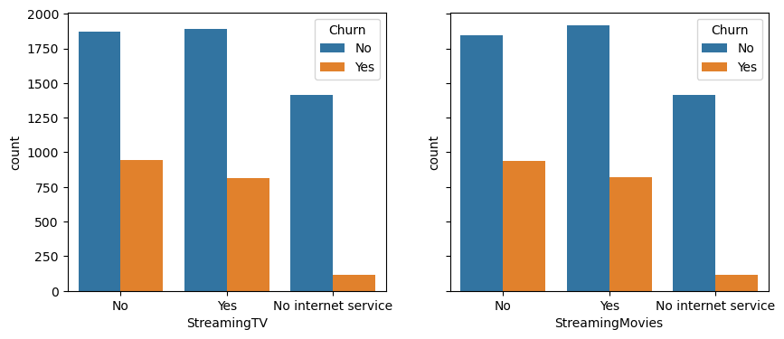

```python
fig, axes = plt.subplots(1, 2, sharey=True, figsize=(10, 4))

sns.countplot(x="StreamingTV", hue="Churn", data=df, ax=axes[0])
sns.countplot(x="StreamingMovies", hue="Churn", data=df, ax=axes[1]);
```

The countplot above gives more insight into the churn by the Streaming TV and Streaming movies. Basic understanding shows the features doesnt significantly impact on the customer churn level. However we will still leave the features

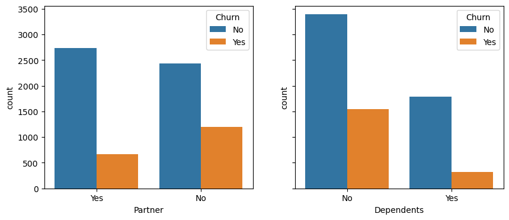

```python
fig, axes = plt.subplots(1, 2, sharey=True, figsize=(10, 4))

sns.countplot(x="Partner", hue="Churn", data=df, ax=axes[0])
sns.countplot(x="Dependents", hue="Churn", data=df, ax=axes[1]);
```

From the countplotabove customer with a No Partners tend to churn more although this doesnt seem to make much of an impact since customers with partners and no partners have almost same level of retention. Also customer with no dependents also tend to churn more but they also have higher retention level. This simply doesnt give a clear picture of how this features affect our target feature

[figure not shown]

```python
plt.figure(figsize=(6, 4))
corr = df.corr(numeric_only=True)
sns.heatmap(corr, annot=True, cmap='coolwarm')
plt.title('Correlation Heatmap')
plt.show()
```